# DV2_Homework

## 0. Load the nycflights13 package and check what kind of datasets exist in the package, then create a copy of flights dataset into a data.table object, called flight_data.

```r
data(package ="nycflights13")$results[,c("Item", "Title")]
```

```
##      Item       Title
## [1,] "airlines" "Airline names."
## [2,] "airports" "Airport metadata"
## [3,] "flights"  "Flights data"
## [4,] "planes"   "Plane metadata."
## [5,] "weather"  "Hourly weather data"
```

```r
flight_data <- data.table(nycflights13::flights)
```

## 1. Which destination had the lowest avg arrival delay from LGA with minimum 100 flight to that destination?

```r
flight_data[origin== "LGA", list(number_of_flights = .N,
                                 mean_arr_delay= mean(arr_delay,na.rm = T)),
            by= dest][number_of_flights >= 100][order(mean_arr_delay)][1]
```

```
##    dest number_of_flights mean_arr_delay
## 1:  DAY               391      -4.947368
```

Or a second method:

```r
flight_data %>%
  filter(origin == 'LGA') %>%
  group_by(dest) %>%
  summarise(n = n(), mean_arr_delay = mean(arr_delay, na.rm=T) ) %>%
  filter(n >=100)%>%
  arrange(mean_arr_delay) %>%
  head(1)
```

```
## # A tibble: 1 x 3
##   dest      n mean_arr_delay
##   <chr> <int>          <dbl>
## 1 DAY     391          -4.95
```

## 2. Which destination’s flights were the most on time (avg arrival delay closest to zero) from LGA with minimum 100 flight to that destination?

```r
flight_data[origin== "LGA", list(number_of_flights = .N,
                                 mean_arr_delay= abs(mean(arr_delay,na.rm = T))),
            by= dest][number_of_flights >= 100][order(mean_arr_delay)][1]
```

```
##    dest number_of_flights mean_arr_delay
## 1:  MIA              5781      0.0657664
```

## 3. Who is the manufacturer of the plane, which flights the most to CHS destination?

```r
planes <- data.table(nycflights13::planes)

merge(planes,
  flight_data[dest== "CHS",  .(number_of_flights=.N), by = tailnum],
  by = 'tailnum')[, list(tailnum,number_of_flights,manufacturer)][order(-number_of_flights)][1]
```

```
##    tailnum number_of_flights   manufacturer
## 1:  N713EV                22 BOMBARDIER INC
```

Or a second method:

```r
merge(flight_data,planes, by="tailnum")[dest == "CHS",list(number_of_flights = .N,
                                                           manufacturer),
           by= tailnum][order(-number_of_flights)][1]
```

```
##    tailnum number_of_flights   manufacturer
## 1:  N713EV                22 BOMBARDIER INC
```

## 4. Which airline (carrier) flow the most by distance?

```r
carrier_data <- nycflights13::airlines

merge(flight_data,carrier_data, by="carrier")[, list(sum_of_distance= sum(distance)),
by= name][order(-sum_of_distance)][1]
```

```
##                     name sum_of_distance
## 1: United Air Lines Inc.        89705524
```

## 5. Plot the monthly number of flights with 20+ mins arrival delay!

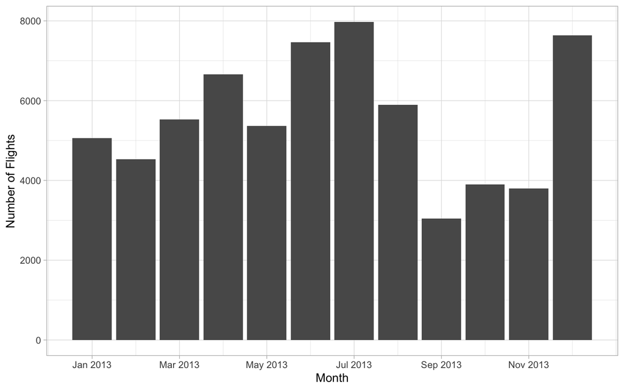

```r
flight_data[arr_delay > 20, list(number_of_flights = .N), by = month] %>%
  ggplot(aes(x= month, y=number_of_flights)) +
  geom_col() +
  labs(x="Month", y= "Number of Flights") +
  scale_x_continuous(breaks=seq(1, 12, by = 2),
                     labels = c(paste0(month.abb[seq(1, 12, by = 2)], " 2013")))
```

## 6. Plot the departure delay of flights going to IAH and the related day’s wind speed on a scaterplot! Is there any association between the two variables? Try adding a linear model.

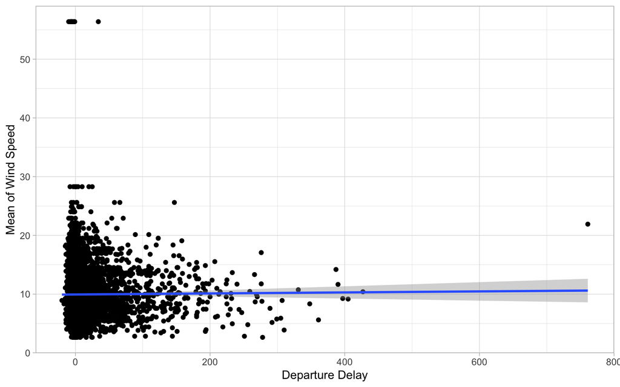

```r
weather <- data.table(nycflights13::weather)

merge(weather[, .(mean_ws=mean(wind_speed)), by = list(year, month, day, origin)],
  flight_data[dest== "IAH",  .(dep_delay,origin), by = list(year, month, day)],
  by = c('year', 'month', 'day', 'origin')) %>%
ggplot(aes(x= dep_delay,y=mean_ws))+
  geom_point() +
  geom_smooth(method = 'lm')+
  labs(x="Departure Delay",y="Mean of Wind Speed")
```

## 7. Plot the airports as per their geolocation on a world map, by mapping the number flights going to that destionation to the size of the symbol!

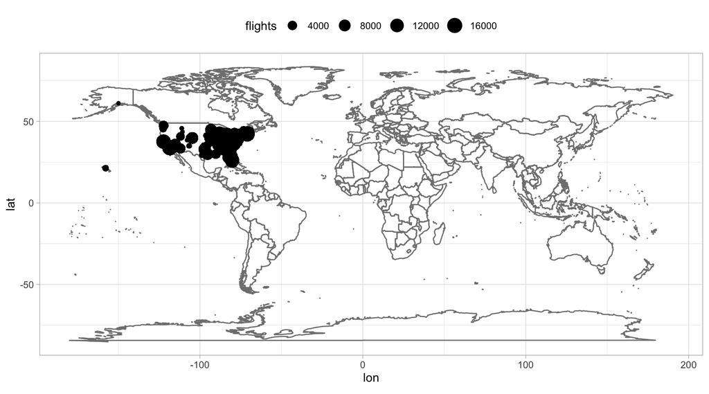

```r
airport_data <- data.table(airports)

merge(airport_data[,list(faa,lat,lon)],
      flight_data,
      by.x="faa", by.y="dest")[, .(lon, lat,flights=.N), by = faa] %>%
  ggplot(aes(lon, lat, size = flights)) +
  borders("world") +
  geom_point() +
  coord_quickmap()+
  theme(legend.position="top")
```

Or a second method:

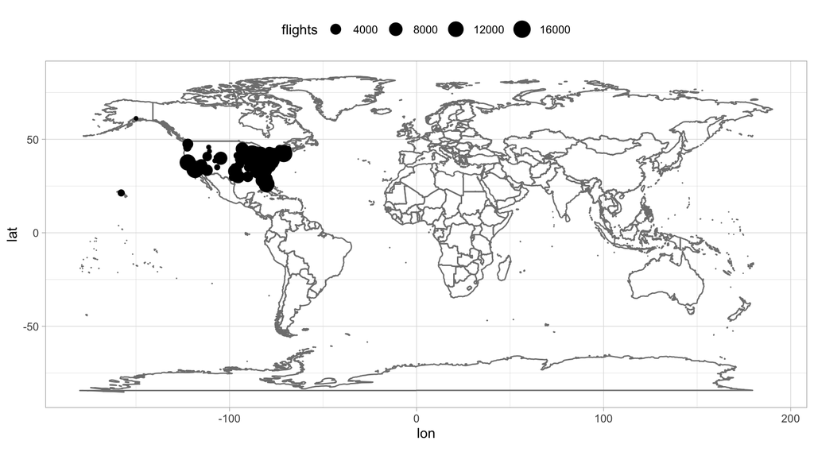

```r
  flight_data %>%
  group_by(dest) %>%
  summarise(flights = n()) %>%
  inner_join(airports, by = c(dest = "faa"))%>%
  ggplot(aes(lon, lat, size = flights)) +
  borders("world") +
  geom_point() +
  coord_quickmap()+
  theme(legend.position="top")
```